# Last Quarter’s Review

Week 1

Published

January 9, 2025

# Before we start

- We are expected to have installed R and RStudio, if not see the installing R section.
- In the discussion section, we will focus on coding and practicing what we have learned in the lectures.
- Office hours are on Tuesday, 11-12:30 Scott 110.
- Questions?

[Download script](https://artur-baranov.github.io/nu-ps405-ds/scripts/ps405-d_1.qmd)

# Brief recap of the last quarter

## Coding Terminology

### Code Chunk

To insert a **Code Chunk**, you can use `Ctrl+Alt+I` on Windows and `Cmd+Option+I` on Mac. Run the whole chunk by clicking the green triangle, or one/multiple lines by using `Ctrl + Enter` or `Command + Return` on Mac.

```r
print("Code Chunk")
```

```
[1] "Code Chunk"
```

### Function and Arguments

Most of the **functions** we want to run require an **argument** For example, the function `print()` above takes the argument “Code Chunk”.

```r
function(argument)
```

### Data structures

There are many **data structures**, but the most important to know the following.

- **Objects.** Those are individual units, e.g. a number or a word.

```r
number = 1
number

word = "Northwestern"
word
```

```
[1] 1
[1] "Northwestern"
```

- **Vectors**. Vectors are collections of objects. To create one, you will need to use function `c()`.

```r
numbers = c(1, 2, 3)
numbers
```

```
[1] 1 2 3
```

- **Dataframes**. Dataframes are the most used data structure. Last quarter you spend a lot of time working with it. It is a table with data. Columns are called variables, and those are vectors. You can access a column using `$` operator.

```r
df = data.frame(numbers,
                numbers_multiplied = numbers * 2)
df
df$numbers_multiplied
```

```
  numbers numbers_multiplied
1       1                  2
2       2                  4
3       3                  6
[1] 2 4 6
```

### Data classes

We work with various **classes of data**, and the analysis we perform depends heavily on these classes.

- **Numeric**. Continuous data.

```r
numeric_class = c(1.2, 2.5, 7.3)
numeric_class
class(numeric_class)
```

```
[1] 1.2 2.5 7.3
[1] "numeric"
```

- **Integer**. Whole numbers (e.g., count data).

```r
integer_class = c(1:3)
class(integer_class)
```

```
[1] "integer"
```

- **Character**. Usually, represent textual data.

```r
word
```

```
[1] "Northwestern"
```

```r
class(word)
```

```
[1] "character"
```

- **Factor**. Categorical variables, where each value is treated as an identifier for a category.

```r
colors = c("blue", "green")
class(colors)
```

```
[1] "character"
```

As you noticed, R did not identify the class of data correctly. We can change it using `as.factor()` function. You can easily change the class of your variable (`as.numeric()`, `as.integer()`, `as.character()`)

```r
colors = as.factor(colors)
class(colors)
```

```
[1] "factor"
```

### Libraries

Quite frequently, we use additional **libraries** to extend the capabilities of R. I’m sure you remember `tidyverse`. Let’s load it.

```r
library(tidyverse)
```

If you updated your R or recently downloaded it, you can easily install libraries using the function `install.packages()`.

### Pipes

**Pipes** (`%>%` or `|>`) are helpful for streamlining the coding. They introduce linearity to the process of writing the code. In plain English, a pipe translates to “take an object, and then”.

```r
numbers %>%
  print()
```

```
[1] 1 2 3
```

# Describing Data

First task, let’s load the data

```r
load(url("https://github.com/vdeminstitute/vdemdata/raw/6bee8e170578fe8ccdc1414ae239c5e870996bc0/data/vdem.RData"))
```

This is the V-Dem dataset. For your reference, their codebook is available [here](https://v-dem.net/documents/38/V-Dem_Codebook_v14.pdf).

The dataset is huge! Be careful

```r
nrow(vdem)
ncol(vdem)
```

```
[1] 27734
[1] 4607
```

Imagine you are interested in the relationship between regime type and physical violence. Let’s **select** the variables we will work with. Quite unfortunately, the names of the variables are not as straightforward. The regime index is `e_v2x_polyarchy_5C` and Physical violence index is `v2x_clphy`.

```r
violence_data = vdem %>%
  select(country_name, year, e_v2x_polyarchy_5C, v2x_clphy)
```

Let’s **rename** the variables so it’s easier to work with them.

```r
violence_data = violence_data %>%
  rename(regime = e_v2x_polyarchy_5C,
         violence = v2x_clphy)

head(violence_data)
```

```
  country_name year regime violence
1       Mexico 1789      0    0.322
2       Mexico 1790      0    0.322
3       Mexico 1791      0    0.322
4       Mexico 1792      0    0.322
5       Mexico 1793      0    0.322
6       Mexico 1794      0    0.322
```

Now, analyze the regime data. We can describe regime data using various statistics. Let’s check the min score for the regime.

```r
min(violence_data$regime, na.rm = T)
```

```
[1] 0
```

Check the max score for the regime variable below.

```r
...(violence_data$regime, na.rm = T)
```

Check the average score for the regime variable below.

```r
mean(..., na.rm = T)
```

Finally, use the `summary()` function to get the descriptive statistics.

```r
summary(violence_data$regime)
```

```
   Min. 1st Qu.  Median    Mean 3rd Qu.    Max.    NA's
 0.0000  0.0000  0.0000  0.2224  0.2500  1.0000    1139
```

**Exercise**

Select country name (`contry_name`), year (`year`) and Political corruption index (`v2x_corr`) from the `vdem` dataset.

```r
corruption = vdem %>%
  ...(contry_name, ...)
```

Leave only year 2010 using `filter()` function

```r
corruption = corruption
  ...
```

Calculate min, max and median. Don’t forget about missing values, `na.rm = TRUE` argument should remove them.

```r
...(corruption$v2x_corr)
```

Present the summary

You can use the table below for your reference.

| Statistic | Function | Example Usage |
| --- | --- | --- |
| Minimum | `min()` | `min(x)` |
| Maximum | `max()` | `max(x)` |
| Mean | `mean()` | `mean(x)` |
| Median | `median()` | `median(x)` |
| Standard Deviation | `sd()` | `sd(x)` |
| Variance | `var()` | `var(x)` |
| Sum | `sum()` | `sum(x)` |
| Summary | `summary()` | `summary(x)` |

# Vizualization

Let’s begin with analyzing the distribution of the Violence Index in the year 2000. We need to **filter** the data for this task.

```r
violence_2000 = violence_data %>%
  filter(year == 2000)
```

The higher the number, the better the physical integrity in a given country.

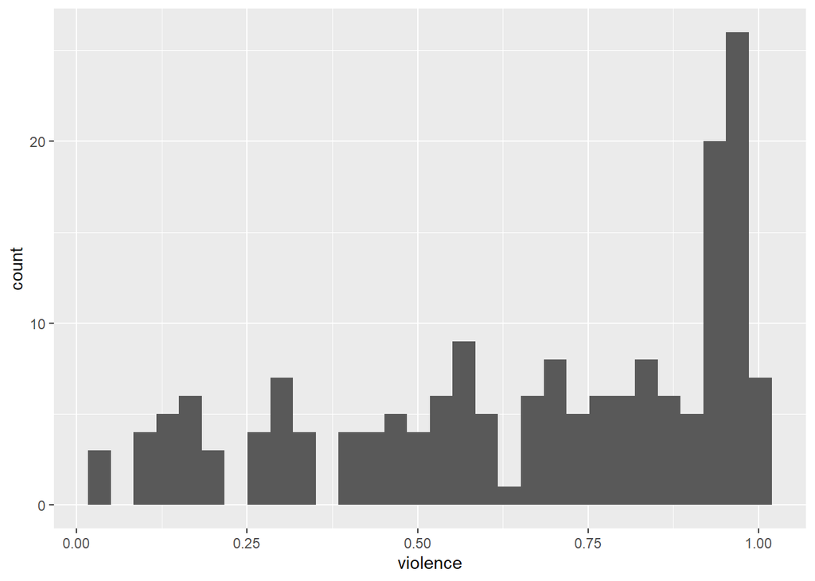

```r
ggplot(data = violence_2000) +
  geom_histogram(aes(x = violence))
```

Let’s customize the plot a bit.

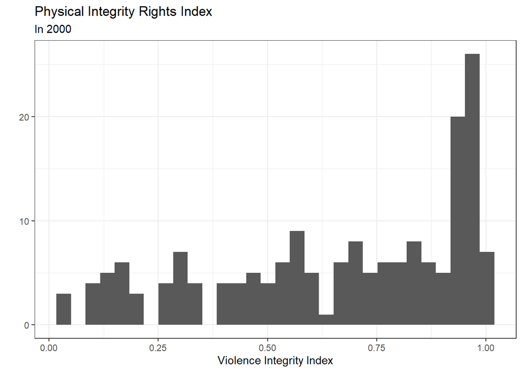

```r
ggplot(data = violence_2000) +
  geom_histogram(aes(x = violence)) +
  labs(title = "Physical Integrity Rights Index",
       subtitle = "In 2000",
       x = "Violence Integrity Index",
       y = "") +
  theme_bw()
```

Imagine, you asked the following question. Is it true that in the year 2000 democracies had better violence integrity rights index?

Firstly, you we need to differentiate between the regimes. Using `mutate()` function we can create and modify existing variables. Let’s do that!

```r
violence_2000 = violence_2000 %>%
  mutate(democracy = case_when(regime >= 0.5 ~ "Democracy",
                               regime < 0.5 ~ "Autocracy"))

head(violence_2000)
```

```
  country_name year regime violence democracy
1       Mexico 2000   0.75    0.573 Democracy
2     Suriname 2000   0.75    0.871 Democracy
3       Sweden 2000   1.00    0.990 Democracy
4  Switzerland 2000   1.00    0.974 Democracy
5        Ghana 2000   0.75    0.946 Democracy
6 South Africa 2000   0.75    0.834 Democracy
```

There are multiple ways to visually compare between two groups.

Let’s draw histograms first.

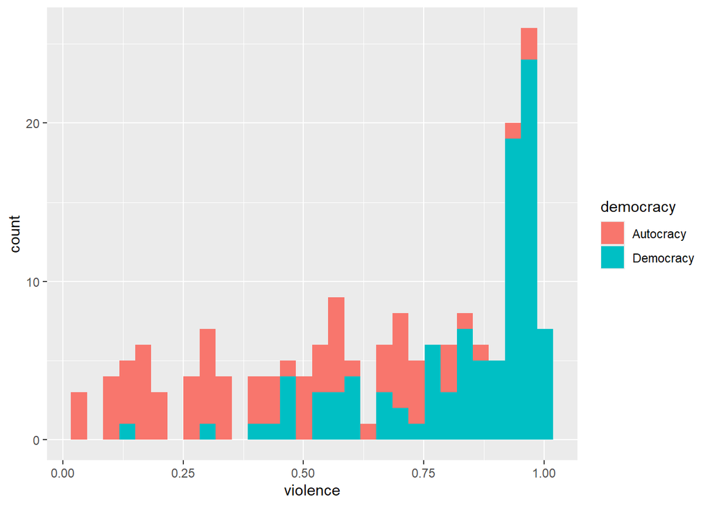

```r
ggplot(violence_2000) +
  geom_histogram(aes(x = violence, fill = democracy))
```

But comparing distributions between groups is easier with the boxplot. But are they different?

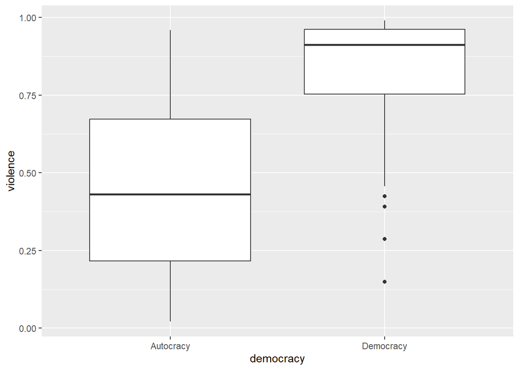

```r
ggplot(violence_2000) +
  geom_boxplot(aes(x = democracy, y = violence))
```

Let’s try to reverse engineer the data-generating process and calculate the confidence intervals for those samples to double-check the results. We need to `group_by()` type of the regime, and then `summarize()` the data.

```r
violence_ci = violence_2000 %>%
  group_by(democracy) %>%
  summarize(
    mean_violence = mean(violence, na.rm = TRUE),
    lower = mean_violence - 1.96 * sd(violence, na.rm = TRUE) / sqrt(n()),
    upper = mean_violence + 1.96 * sd(violence, na.rm = TRUE) / sqrt(n()))

violence_ci
```

```
# A tibble: 2 × 4
  democracy mean_violence lower upper
  <chr>             <dbl> <dbl> <dbl>
1 Autocracy         0.443 0.386 0.499
2 Democracy         0.827 0.791 0.864
```

Finally, visualize it.

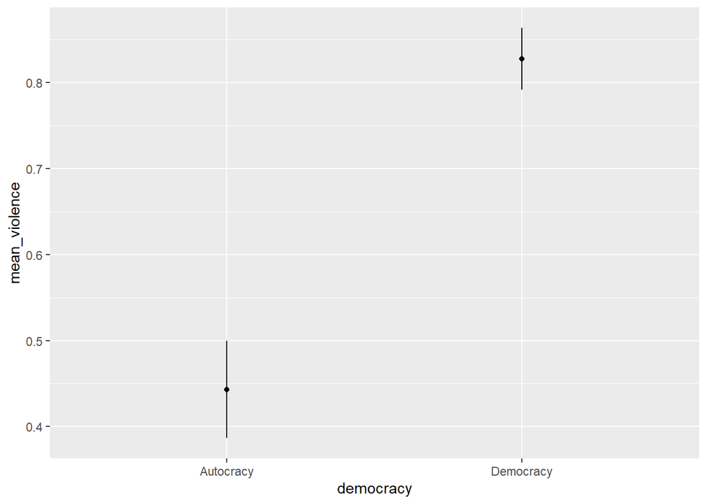

```r
ggplot(violence_ci) +
  geom_linerange(aes(x = democracy,
                     ymin = lower,
                     ymax = upper)) +
  geom_point(aes(x = democracy,
                 y = mean_violence))
```

**Exercise**

Add title, and rename X and Y axis.

```r
ggplot(violence_ci) +
  geom_linerange(aes(x = democracy,
                     ymin = lower,
                     ymax = upper)) +
  geom_point(aes(x = democracy,
                 y = mean_violence)) +
  labs()
```

Draw a histogram of Political corruption index (`v2x_corr`) from the exercises above.

```r
...(corruption)
  geom_...()
```

# Sampling

Lastly, sampling. Imagine, we have data for the whole “population”. In our case, these are all countries in the year 2000. We know average of violence index, which is

```r
mean(violence_2000$violence)
```

```
[1] 0.6601921
```

Compare it to the sample of N = 15

```r
set.seed(1)
violence_sample_15 = sample(violence_2000$violence, size = 15)
```

And now calculate the average of the sample. Is it accurate?

```r
mean(violence_sample_15)
```

```
[1] 0.6147333
```

Let’s repeat (iterate) the process multiple times. First, create an empty dataset to store the data

```r
sample_averages = data.frame()
```

Second, repeat the process 100 times

```r
for(i in 1:100){
  temporary_sample = sample(violence_2000$violence, size = 15)
  temporary_sample_average = mean(temporary_sample)
  sample_averages = rbind(sample_averages, temporary_sample_average)
}
```

Check what we have got

```r
colnames(sample_averages) = "average"
head(sample_averages)
```

```
    average
1 0.6158000
2 0.6850667
3 0.7190000
4 0.6084667
5 0.5105333
6 0.5528000
```

Take a look on the average of the collected averages. Did it get closer to the real parameter? This is essentially **bootstrapping**.

```r
mean(sample_averages$average)
```

```
[1] 0.6461693
```

Draw a histogram of the averages.

```r
...(...)
  geom_histogram(aes(...))
```

# Useful Tidyverse Functions

You can use the table below for your reference.

| Function | Description |
| --- | --- |
| `select()` | Selects specific columns from a data frame |
| `mutate()` | Adds new variables or modifies existing ones |
| `filter()` | Filters rows based on specified conditions |
| `group_by()` | Groups data by one or more variables for subsequent operations |
| `summarize()` | Summarizes data by applying a function (e.g., mean, sum) |
| `case_when()` | Modifies a variable based on conditional logic |
| `rename()` | Renames columns in a data frame |

You can check how to use these commands in this scipt, or you can simply use the help option `?function()`.

# Helpful to review

- [Summarizing Random Variables](https://gustavodiaz.org/ps403/slides/week3.html#/expected-value)
- [Random Samples](https://gustavodiaz.org/ps403/slides/week4.html#/ingredients-for-statistical-inference)
- p-values

# Installing R and RStudio

**First**, we need to install R. Click the button below and click “Download and Install R”. Choose your OS. For Windows you need to download “**base**”; for MacOS and Linux you have to choose the version of your OS. Install.

[Download R](https://cran.rstudio.com)

**Step one**

[figure not shown]

For windows:

[figure not shown]

**Second**, we need to install RStudio. Click the button below and click “Download RStudio Desktop”. You will be redirected to your version automatically. Install.

[Download RStudio](https://posit.co/download/rstudio-desktop/)

**Step two**

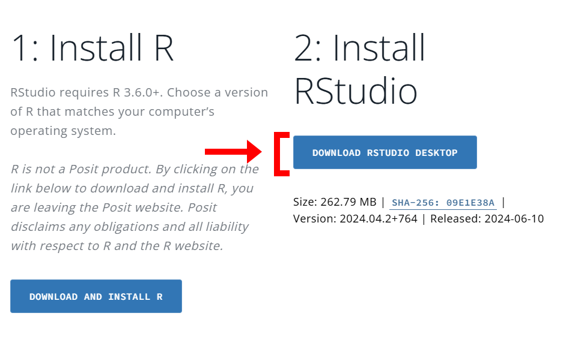